# DonghanLiuHW02

Donghan Liu, Donghan2

2018/2/4

# Solution

## Exercise 1

```r
library(biganalytics)
library(data.table)
library(kableExtra)
library(knitr)
```

```r
data0708 = attach.big.matrix("air0708.desc")
may0708 = data0708[data0708[,"Month"] == 5,]
nodelay = c(rep(0,7))
for (i in 1:7){
  nodelay[i] = nrow(may0708[may0708[,'ArrDelay']<=0 & may0708[,'DayOfWeek']==i & may0708[,'DepDelay']<=0 & may0708[,'WeatherDelay']<=0 & may0708[,'Cancelled']<=0
                             & may0708[,'LateAircraftDelay']<=0 & may0708[,'NASDelay']<=0 & may0708[,'SecurityDelay']<=0 & may0708[,'CarrierDelay']<=0 & may0708[,'Diverted']<=0,])
}

dayofweek = c('Mon','Tue', 'Wed', 'Thu','Fri', 'Sat', 'Sun')
nodelaytable = data.frame(NumOfNoDelays = nodelay, DayOfWeek = dayofweek)

kable_styling(kable(nodelaytable, format = "html", digits = 2), full_width = FALSE)
```

| NumOfNoDelays | DayOfWeek |
| --- | --- |
| 80210 | Mon |
| 89506 | Tue |
| 86889 | Wed |
| 90185 | Thu |
| 73763 | Fri |
| 81883 | Sat |
| 76424 | Sun |

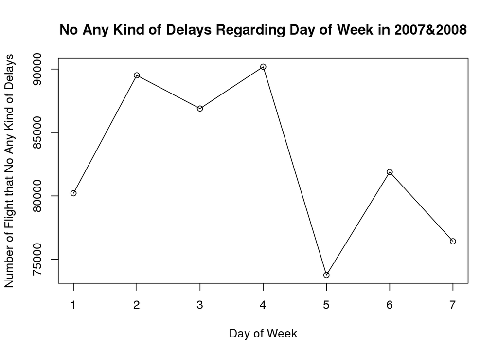

```r
plot(nodelay,type = 'o',main = 'No Any Kind of Delays Regarding Day of Week in 2007&2008',xlab = 'Day of Week',ylab = 'Number of Flight that No Any Kind of Delays')
```

According to the above plot, the Thursday has the most number in no any kind of dalay flights and it potentially would be the best day to travel.

## Exercise 2

```r
noarrdelay = c(rep(0,12))
noarrdelayrate = c(rep(0,12))
for (i in 1:12){
  noarrdelay[i] = nrow(data0708[data0708[,'Month'] == i & data0708[,'ArrDelay'] <= 0,])
  noarrdelayrate[i] = (nrow(data0708[data0708[,'Month'] == i & data0708[,'ArrDelay'] <= 0,])/nrow(data0708[data0708[,'Month'] == i,]))*100
}
monthofyear = c('Jan','Feb', 'Mar', 'Apr','May', 'June', 'July','Aug' ,'Sep','Oct','Nov','Dec')
noarrdelaytable = data.frame(NumOfNoArrDelays = noarrdelay,RateofNoArrDelays_Percent = noarrdelayrate, MonthOfYear = monthofyear)

kable_styling(kable(noarrdelaytable, format = "html", digits = 2), full_width = FALSE)
```

| NumOfNoArrDelays | RateofNoArrDelays_Percent | MonthOfYear |
| --- | --- | --- |
| 625951 | 51.00 | Jan |
| 522749 | 46.06 | Feb |
| 631484 | 50.31 | Mar |
| 659843 | 54.41 | Apr |
| 692531 | 55.94 | May |
| 582953 | 47.09 | June |
| 657138 | 51.48 | July |
| 682699 | 53.94 | Aug |
| 727284 | 63.74 | Sep |
| 720056 | 60.70 | Oct |
| 691734 | 61.30 | Nov |
| 502936 | 43.39 | Dec |

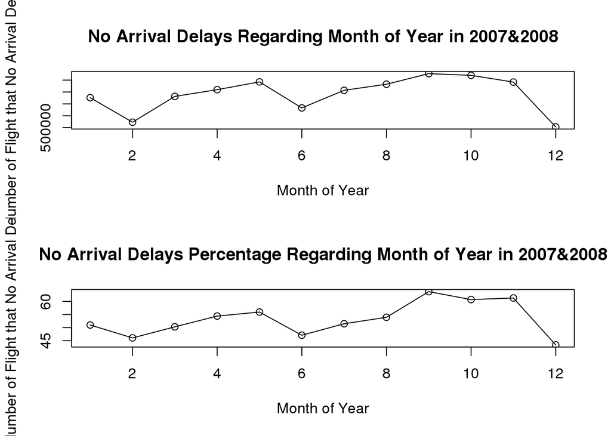

```r
par(mfrow = c(2, 1))
plot(noarrdelay,type = 'o',main = 'No Arrival Delays Regarding Month of Year in 2007&2008',xlab = 'Month of Year',ylab = 'Number of Flight that No Arrival Delays')
plot(noarrdelayrate,type = 'o',main = 'No Arrival Delays Percentage Regarding Month of Year in 2007&2008',xlab = 'Month of Year',ylab = 'Number of Flight that No Arrival Delays')
```

Regarding the above graph and table, the month of Sep has the highest number and rate of no delays, so other than May, Sep is a good option to travel based on avoiding the arrival delays.

## Exercise 3

```r
arrdelay = data0708[,'ArrDelay']
flightime = data0708[,'CRSElapsedTime']
dist = data0708[,'Distance']

#CRSElapsedTime
fitarr = lm(arrdelay ~ flightime)
summary(fitarr)
```

```
##
## Call:
## lm(formula = arrdelay ~ flightime)
##
## Residuals:
##     Min      1Q  Median      3Q     Max
## -529.34  -18.86  -10.20    3.85 2588.58
##
## Coefficients:
##              Estimate Std. Error t value Pr(>|t|)
## (Intercept) 8.5992387  0.0216059  398.00   <2e-16 ***
## flightime   0.0047651  0.0001478   32.23   <2e-16 ***
## ---
## Signif. codes:  0 '***' 0.001 '**' 0.01 '*' 0.05 '.' 0.1 ' ' 1
##
## Residual standard error: 38.93 on 14130315 degrees of freedom
##   (332626 observations deleted due to missingness)
## Multiple R-squared:  7.352e-05,  Adjusted R-squared:  7.344e-05
## F-statistic:  1039 on 1 and 14130315 DF,  p-value: < 2.2e-16
```

Based on the above summary table, we could see that the estimated paramater coefficient is 0.0047651 (positive relationship), the p-value is less than 2e-16, and the R_squared is 7.352-05, which represent the percentage that CRSElapsedTime could explain the arrival delays in 2007-2008

```r
#Distance
fitdist = lm(arrdelay ~ dist)
summary(fitdist)
```

```
##
## Call:
## lm(formula = arrdelay ~ dist)
##
## Residuals:
##     Min      1Q  Median      3Q     Max
## -528.51  -19.12  -10.20    3.81 2588.74
##
## Coefficients:
##              Estimate Std. Error t value Pr(>|t|)
## (Intercept) 9.105e+00  1.688e-02 539.284  < 2e-16 ***
## dist        1.453e-04  1.838e-05   7.906 2.67e-15 ***
## ---
## Signif. codes:  0 '***' 0.001 '**' 0.01 '*' 0.05 '.' 0.1 ' ' 1
##
## Residual standard error: 38.93 on 14130315 degrees of freedom
##   (332626 observations deleted due to missingness)
## Multiple R-squared:  4.423e-06,  Adjusted R-squared:  4.352e-06
## F-statistic:  62.5 on 1 and 14130315 DF,  p-value: 2.666e-15
```

As the above table shows, we could see that the estimated paramater coefficient is 1.453e-04 (week positive relationship), the p-value is 2.67e-15, and the R_squared is 4.423e-06, which represent the percentage that Distance could explain the arrival delays in 2007-2008.

Overall, both of predictors are not the good predictors for the arrival delays, since the R_squared is relatively small. However, if we compare these two predictors, the model that predict arrival delays with CRSElapsedTime is better, since 1. the p-value of the CRSElapsedTime is lower, meaning that it is more significant 2. the model of CRSElapsedTime R_squared is larger, indicating that it explains more to the arrival delays.